# Compile Historical Instream Temperature

Maddee Wiggins (FlowWest)

2026-04-21

### River Mile 6 Instream Temperature

Currently 2012-04-23 - 2025-10-17

**Notes** Rivermile 6 has between 1 and 3 loggers in the stream at any given day/time. The data is process as the average between all loggers with data for each year.

```r
rm_6_historical |>
  group_by(year = year(date)) |>
  summarise(mean_temperature = mean(temperature, na.rm = T),
            min_temperature = min(temperature, na.rm = T),
            max_temperature = max(temperature, na.rm = T)) |>
  knitr::kable(digits = 2)
```

| year | mean_temperature | min_temperature | max_temperature |
| --- | --- | --- | --- |
| 2012 | 11.63 | 2.94 | 21.04 |
| 2013 | 12.10 | 0.04 | 24.12 |
| 2014 | 14.01 | 2.70 | 21.73 |
| 2015 | 14.47 | 1.86 | 25.41 |
| 2016 | 13.05 | 3.87 | 23.49 |
| 2017 | 14.45 | 4.28 | 23.09 |
| 2018 | 13.71 | -0.03 | 25.72 |
| 2019 | 13.30 | -0.03 | 25.45 |
| 2020 | 14.00 | -0.05 | 26.66 |
| 2021 | 10.31 | 3.04 | 17.63 |
| 2022 | 13.23 | -1.58 | 25.11 |
| 2024 | 14.64 | 2.70 | 25.98 |
| 2025 | 14.27 | 2.65 | 24.25 |

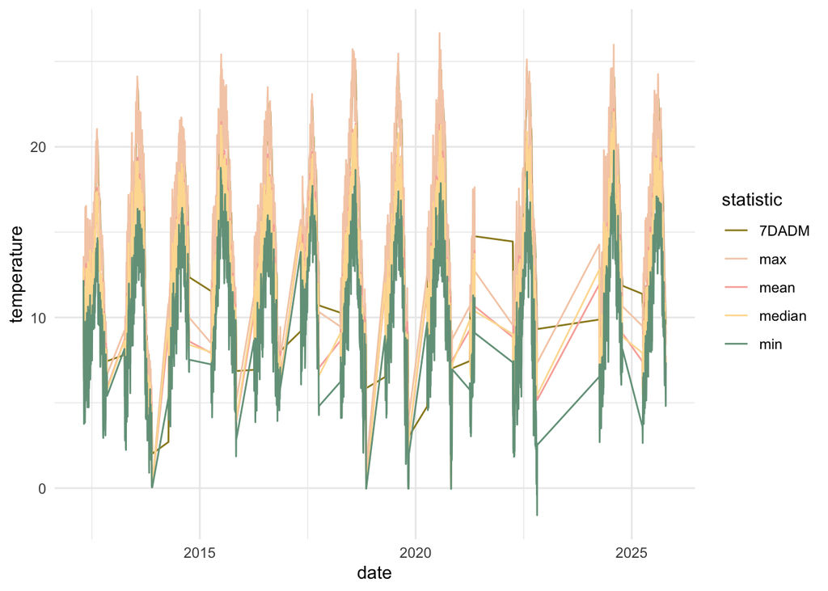

```r
ggplot() +
  geom_line(data = rm_6_historical, aes(x = date, y = temperature, color = statistic)) +
  scale_color_manual(values = colors_small) +
  theme_minimal()
```

### Camp Polk Instream Temperature and Discharge

```r
cp_daily_mean_temperature <-  get_owrd_hydro(
  station_nbr = "14076100",
  start_date = '2011-05-01',
  end_date = Sys.Date()-1,
  data_source = "WTEMP_MEAN"
) |>
  rename(value = daily_mean_water_temp_c) |>
  mutate(variable = "water temperature (c)",
         statistic = "mean",
         location = "camp polk") |>
  glimpse()


cp_daily_min_temperature <-  get_owrd_hydro(
  station_nbr = "14076100",
  start_date = '2011-05-01',
  end_date = Sys.Date()-1,
  data_source = "WTEMP_MIN"
) |>
  rename(value = daily_min_water_temp_f) |>
  mutate(variable = "water temperature (c)",
         statistic = "min",
         location = "camp polk") |>
  select(-time_observed) |>
  glimpse()

cp_daily_max_temperature <-  get_owrd_hydro(
  station_nbr = "14076100",
  start_date = '2011-05-01',
  end_date = Sys.Date()-1,
  data_source = "WTEMP_MAX"
) |>
  rename(value = daily_max_water_temp_c) |>
  mutate(variable = "water temperature (c)",
         statistic = "max",
         location = "camp polk") |>
  select(-time_observed) |>
  glimpse()

cp_mean_daily_flow <-  get_owrd_hydro(
  station_nbr = "14076100",
  start_date = '2011-05-01',
  end_date = Sys.Date()-1,
  data_source = "MDF"
) |>
  rename(value = mean_daily_flow_cfs) |>
  mutate(variable = "discharge (cfs)",
         statistic = "mean",
         location = "camp polk") |>
  glimpse()

camp_polk_historical_raw <- bind_rows(
  cp_daily_max_temperature,
  cp_daily_min_temperature,
  cp_daily_mean_temperature,
  cp_mean_daily_flow
) |>
  rename(date = record_date) |>
  mutate(date = as.Date(
    parse_date_time(date, orders = c("mdy", "mdy HM"))
  )) |>
  glimpse()

camp_polk_historical <- camp_polk_historical_raw |>
  filter(statistic == "max") |>
  filter(variable == "water temperature (c)") |>
  arrange(date) |>
  mutate(value = zoo::rollapply(value, width = 7, FUN = mean,
                                      fill = NA, align = "right"),
         statistic = "7DADM") |>
  bind_rows(camp_polk_historical_raw) |>
  arrange(date)

camp_polk_flow_historical <- camp_polk_historical_raw |>
  filter(variable == "discharge (cfs)") |>
  select(date, flow_cfs = value, statistic) |>
  arrange(date) |>
  glimpse()

usethis::use_data(camp_polk_flow_historical, overwrite = T)
```

```r
whychusModel::camp_polk_historical |>
  group_by(year = year(date), statistic, variable) |>
  summarise(n_values = n()) |>
  knitr::kable()
```

```
## `summarise()` has regrouped the output.
## ℹ Summaries were computed grouped by year, statistic, and variable.
## ℹ Output is grouped by year and statistic.
## ℹ Use `summarise(.groups = "drop_last")` to silence this message.
## ℹ Use `summarise(.by = c(year, statistic, variable))` for per-operation
##   grouping (`?dplyr::dplyr_by`) instead.
```

| year | statistic | variable | n_values |
| --- | --- | --- | --- |
| 2011 | mean | discharge (cfs) | 245 |
| 2012 | mean | discharge (cfs) | 366 |
| 2013 | mean | discharge (cfs) | 365 |
| 2014 | mean | discharge (cfs) | 365 |
| 2015 | max | water temperature (c) | 92 |
| 2015 | mean | discharge (cfs) | 365 |
| 2015 | mean | water temperature (c) | 92 |
| 2015 | min | water temperature (c) | 92 |
| 2016 | max | water temperature (c) | 366 |
| 2016 | mean | discharge (cfs) | 366 |
| 2016 | mean | water temperature (c) | 366 |
| 2016 | min | water temperature (c) | 366 |
| 2017 | max | water temperature (c) | 365 |
| 2017 | mean | discharge (cfs) | 365 |
| 2017 | mean | water temperature (c) | 365 |
| 2017 | min | water temperature (c) | 365 |
| 2018 | max | water temperature (c) | 365 |
| 2018 | mean | discharge (cfs) | 365 |
| 2018 | mean | water temperature (c) | 365 |
| 2018 | min | water temperature (c) | 365 |
| 2019 | max | water temperature (c) | 365 |
| 2019 | mean | discharge (cfs) | 365 |
| 2019 | mean | water temperature (c) | 365 |
| 2019 | min | water temperature (c) | 365 |
| 2020 | max | water temperature (c) | 366 |
| 2020 | mean | discharge (cfs) | 366 |
| 2020 | mean | water temperature (c) | 366 |
| 2020 | min | water temperature (c) | 366 |
| 2021 | max | water temperature (c) | 365 |
| 2021 | mean | discharge (cfs) | 365 |
| 2021 | mean | water temperature (c) | 365 |
| 2021 | min | water temperature (c) | 365 |
| 2022 | max | water temperature (c) | 365 |
| 2022 | mean | discharge (cfs) | 365 |
| 2022 | mean | water temperature (c) | 365 |
| 2022 | min | water temperature (c) | 365 |
| 2023 | max | water temperature (c) | 365 |
| 2023 | mean | discharge (cfs) | 365 |
| 2023 | mean | water temperature (c) | 365 |
| 2023 | min | water temperature (c) | 365 |
| 2024 | max | water temperature (c) | 366 |
| 2024 | mean | discharge (cfs) | 366 |
| 2024 | mean | water temperature (c) | 366 |
| 2024 | min | water temperature (c) | 366 |
| 2025 | max | water temperature (c) | 365 |
| 2025 | mean | discharge (cfs) | 365 |
| 2025 | mean | water temperature (c) | 365 |
| 2025 | min | water temperature (c) | 365 |
| 2026 | max | water temperature (c) | 104 |
| 2026 | mean | discharge (cfs) | 104 |
| 2026 | mean | water temperature (c) | 104 |
| 2026 | min | water temperature (c) | 104 |

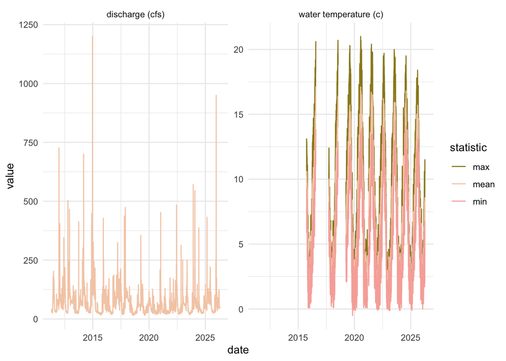

```r
ggplot() +
  geom_line(data = whychusModel::camp_polk_historical, aes(x = date, y = value, color = statistic)) +
  scale_color_manual(values = colors_small) +
  facet_wrap(~variable, scales = "free_y") +
  theme_minimal()
```

### Whychus Cr Near Sisters - Instream Temperature and Flow

This site is located upstream of Sisters. It collects temperature and flow.

```r
wns_daily_mean_temperature <-  get_owrd_hydro(
  station_nbr = "14075000",
  start_date = '2011-01-01',
  end_date = Sys.Date(),
  data_source = "WTEMP_MEAN"
) |>
  rename(value = daily_mean_water_temp_c) |>
  mutate(variable = "water temperature (c)",
         statistic = "mean",
         location = "whychus cr nr sisters, or") |>
  glimpse()


wns_daily_min_temperature <-  get_owrd_hydro(
  station_nbr = "14075000",
  start_date = '2011-01-01',
  end_date = Sys.Date(),
  data_source = "WTEMP_MIN"
) |>
  rename(value = daily_min_water_temp_f) |>
  mutate(variable = "water temperature (c)",
         statistic = "min",
         location = "whychus cr nr sisters, or") |>
  select(-time_observed) |>
  glimpse()

wns_daily_max_temperature <-  get_owrd_hydro(
  station_nbr = "14075000",
  start_date = '2011-01-01',
  end_date = Sys.Date(),
  data_source = "WTEMP_MAX"
) |>
  rename(value = daily_max_water_temp_c) |>
  mutate(variable = "water temperature (c)",
         statistic = "max",
         location = "whychus cr nr sisters, or") |>
  select(-time_observed) |>
  glimpse()

wns_mean_daily_flow <-  get_owrd_hydro(
  station_nbr = "14075000",
  start_date = '2011-01-01',
  end_date = Sys.Date(),
  data_source = "MDF"
) |>
  rename(value = mean_daily_flow_cfs) |>
  mutate(variable = "discharge (cfs)",
         statistic = "mean",
         location = "whychus cr nr sisters, or") |>
  glimpse()

whychus_nr_sisters_historical <- bind_rows(
  wns_daily_max_temperature,
  wns_daily_min_temperature,
  wns_daily_mean_temperature,
  wns_mean_daily_flow
) |>
  rename(date = record_date) |>
  mutate(date = as.Date(
    parse_date_time(date, orders = c("mdy", "mdy HM"))
  )) |>
  glimpse()

usethis::use_data(whychus_nr_sisters_historical, overwrite = T)
```

```r
whychus_nr_sisters_historical |>
  group_by(year = year(date), statistic, variable) |>
  summarise(n_values = n()) |>
  knitr::kable()
```

```
## `summarise()` has regrouped the output.
## ℹ Summaries were computed grouped by year, statistic, and variable.
## ℹ Output is grouped by year and statistic.
## ℹ Use `summarise(.groups = "drop_last")` to silence this message.
## ℹ Use `summarise(.by = c(year, statistic, variable))` for per-operation
##   grouping (`?dplyr::dplyr_by`) instead.
```

| year | statistic | variable | n_values |
| --- | --- | --- | --- |
| 2011 | mean | discharge (cfs) | 365 |
| 2012 | mean | discharge (cfs) | 366 |
| 2013 | mean | discharge (cfs) | 365 |
| 2014 | mean | discharge (cfs) | 365 |
| 2015 | mean | discharge (cfs) | 365 |
| 2016 | max | water temperature (c) | 366 |
| 2016 | mean | discharge (cfs) | 366 |
| 2016 | mean | water temperature (c) | 366 |
| 2016 | min | water temperature (c) | 366 |
| 2017 | max | water temperature (c) | 365 |
| 2017 | mean | discharge (cfs) | 365 |
| 2017 | mean | water temperature (c) | 365 |
| 2017 | min | water temperature (c) | 365 |
| 2018 | max | water temperature (c) | 365 |
| 2018 | mean | discharge (cfs) | 365 |
| 2018 | mean | water temperature (c) | 365 |
| 2018 | min | water temperature (c) | 365 |
| 2019 | max | water temperature (c) | 365 |
| 2019 | mean | discharge (cfs) | 365 |
| 2019 | mean | water temperature (c) | 365 |
| 2019 | min | water temperature (c) | 365 |
| 2020 | max | water temperature (c) | 366 |
| 2020 | mean | discharge (cfs) | 366 |
| 2020 | mean | water temperature (c) | 366 |
| 2020 | min | water temperature (c) | 366 |
| 2021 | max | water temperature (c) | 365 |
| 2021 | mean | discharge (cfs) | 365 |
| 2021 | mean | water temperature (c) | 365 |
| 2021 | min | water temperature (c) | 365 |
| 2022 | max | water temperature (c) | 365 |
| 2022 | mean | discharge (cfs) | 365 |
| 2022 | mean | water temperature (c) | 365 |
| 2022 | min | water temperature (c) | 365 |
| 2023 | max | water temperature (c) | 365 |
| 2023 | mean | discharge (cfs) | 365 |
| 2023 | mean | water temperature (c) | 365 |
| 2023 | min | water temperature (c) | 365 |
| 2024 | max | water temperature (c) | 366 |
| 2024 | mean | discharge (cfs) | 366 |
| 2024 | mean | water temperature (c) | 366 |
| 2024 | min | water temperature (c) | 366 |
| 2025 | max | water temperature (c) | 365 |
| 2025 | mean | discharge (cfs) | 365 |
| 2025 | mean | water temperature (c) | 365 |
| 2025 | min | water temperature (c) | 365 |
| 2026 | max | water temperature (c) | 104 |
| 2026 | mean | discharge (cfs) | 105 |
| 2026 | mean | water temperature (c) | 104 |
| 2026 | min | water temperature (c) | 104 |

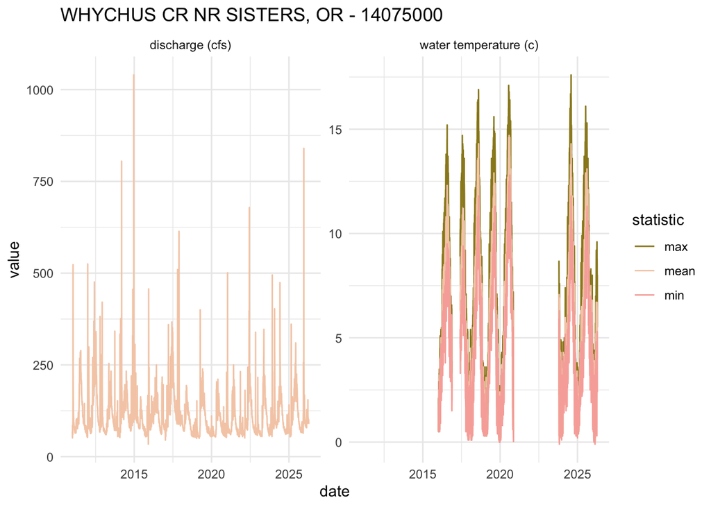

```r
ggplot() +
  geom_line(data = whychus_nr_sisters_historical, aes(x = date, y = value, color = statistic)) +
  scale_color_manual(values = colors_small) +
  facet_wrap(~variable, scales = "free_y") +
  theme_minimal() +
  ggtitle("WHYCHUS CR NR SISTERS, OR - 14075000")
```

### Whychus Cr at Sisters - Flow

This site is in Sisters, Oregon. The site only collects flow.

TODO: change or add instantaneous

```r
was_mean_daily_flow <-  get_owrd_hydro(
  station_nbr = "14076050",
  start_date = '2011-01-01',
  end_date = Sys.Date(),
  data_source = "MDF"
) |>
  rename(value = mean_daily_flow_cfs) |>
  mutate(variable = "discharge (cfs)",
         statistic = "mean",
         location = "whychus cr at sisters, or") |>
  glimpse()

whychus_at_sisters_historical <- was_mean_daily_flow |>
  rename(date = record_date) |>
  mutate(date = as.Date(
    parse_date_time(date, orders = c("mdy", "mdy HM"))
  )) |>
  glimpse()

usethis::use_data(whychus_at_sisters_historical, overwrite = T)
```

```r
whychus_at_sisters_historical |>
  group_by(year = year(date), statistic, variable) |>
  summarise(n_values = n()) |>
  knitr::kable()
```

```
## `summarise()` has regrouped the output.
## ℹ Summaries were computed grouped by year, statistic, and variable.
## ℹ Output is grouped by year and statistic.
## ℹ Use `summarise(.groups = "drop_last")` to silence this message.
## ℹ Use `summarise(.by = c(year, statistic, variable))` for per-operation
##   grouping (`?dplyr::dplyr_by`) instead.
```

| year | statistic | variable | n_values |
| --- | --- | --- | --- |
| 2011 | mean | discharge (cfs) | 365 |
| 2012 | mean | discharge (cfs) | 366 |
| 2013 | mean | discharge (cfs) | 365 |
| 2014 | mean | discharge (cfs) | 365 |
| 2015 | mean | discharge (cfs) | 365 |
| 2016 | mean | discharge (cfs) | 366 |
| 2017 | mean | discharge (cfs) | 365 |
| 2018 | mean | discharge (cfs) | 365 |
| 2019 | mean | discharge (cfs) | 365 |
| 2020 | mean | discharge (cfs) | 366 |
| 2021 | mean | discharge (cfs) | 365 |
| 2022 | mean | discharge (cfs) | 365 |
| 2023 | mean | discharge (cfs) | 365 |
| 2024 | mean | discharge (cfs) | 366 |
| 2025 | mean | discharge (cfs) | 365 |
| 2026 | mean | discharge (cfs) | 105 |

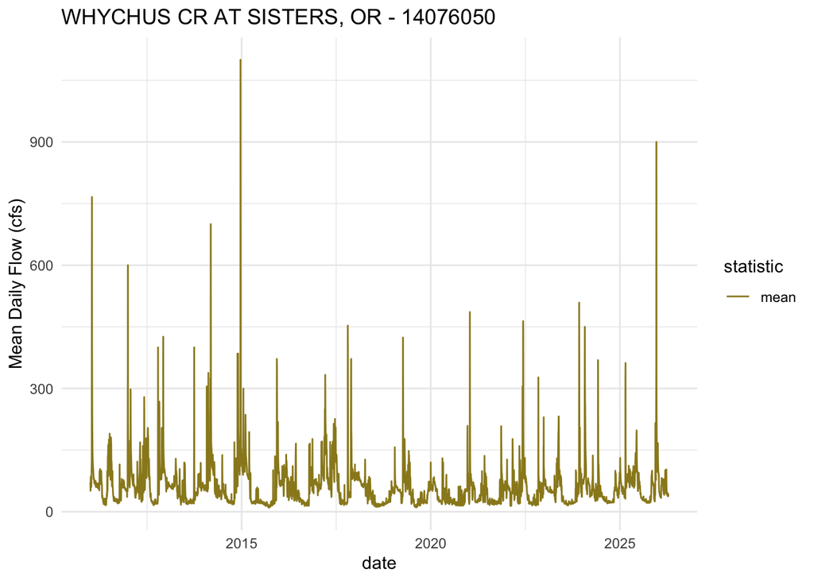

```r
ggplot() +
  geom_line(data = whychus_at_sisters_historical, aes(x = date, y = value, color = statistic)) +
  scale_color_manual(values = colors_small) +
  theme_minimal() +
  ggtitle("WHYCHUS CR AT SISTERS, OR - 14076050") +
  ylab("Mean Daily Flow (cfs)")
```

### River Mile 8.5 Instream Temperature

Collected using a HOBO datalogger by Upper Deschutes Watershed Council

```r
rm_8_5_historical |>
  group_by(year = year(date)) |>
  summarise(mean_temperature = mean(temperature, na.rm = T),
            min_temperature  = min(temperature, na.rm = T),
            max_temperature  = max(temperature, na.rm = T)) |>
  knitr::kable(digits = 2)
```

| year | mean_temperature | min_temperature | max_temperature |
| --- | --- | --- | --- |
| 2011 | 12.33 | 1.60 | 20.50 |
| 2012 | 11.66 | 3.09 | 20.64 |
| 2013 | 13.85 | 1.73 | 23.43 |
| 2014 | 13.11 | 2.39 | 21.86 |
| 2015 | 14.06 | 1.36 | 25.15 |
| 2016 | 12.82 | 1.93 | 23.22 |
| 2017 | 13.26 | 2.29 | 22.78 |
| 2018 | 13.59 | -0.03 | 25.50 |
| 2019 | 13.04 | -0.09 | 24.92 |
| 2020 | 13.95 | 0.02 | 25.82 |
| 2021 | 14.12 | 1.89 | 25.02 |
| 2022 | 12.70 | 1.43 | 24.44 |
| 2024 | 14.49 | 2.52 | 26.01 |
| 2025 | 13.13 | 1.82 | 24.28 |

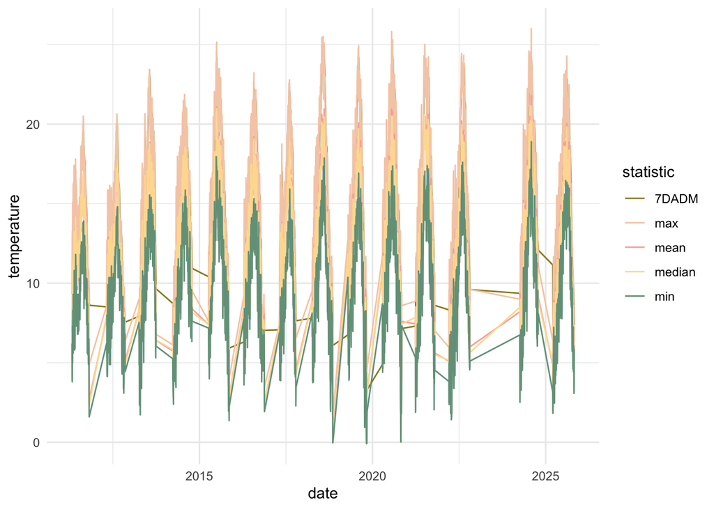

```r
ggplot() +
  geom_line(data = rm_8_5_historical, aes(x = date, y = temperature, color = statistic)) +
  scale_color_manual(values = colors_small) +
  theme_minimal()
```

### UDWC Camp Polk Logger - temperature

Monitoring location description: “d/s Camp Polk Bridge on DBLT property” (WC_019-50)

```r
camp_polk_logger_historical |>
  group_by(year = year(date)) |>
  summarise(mean_temperature = mean(temperature, na.rm = T),
            min_temperature  = min(temperature, na.rm = T),
            max_temperature  = max(temperature, na.rm = T)) |>
  knitr::kable(digits = 2)
```

| year | mean_temperature | min_temperature | max_temperature |
| --- | --- | --- | --- |
| 2012 | 10.38 | 2.95 | 17.92 |
| 2013 | 10.10 | -1.58 | 19.39 |
| 2014 | 10.87 | 2.59 | 18.20 |
| 2015 | 12.14 | 3.08 | 21.21 |
| 2016 | 10.84 | 1.67 | 19.63 |
| 2017 | 10.95 | 2.50 | 17.75 |
| 2018 | 10.82 | 0.72 | 20.01 |
| 2019 | 11.16 | 0.14 | 20.36 |
| 2020 | 12.30 | 1.86 | 20.86 |
| 2021 | 12.14 | 1.53 | 20.36 |
| 2022 | 10.15 | 0.66 | 19.91 |
| 2024 | 11.24 | 2.30 | 19.46 |
| 2025 | 10.51 | 1.63 | 18.48 |

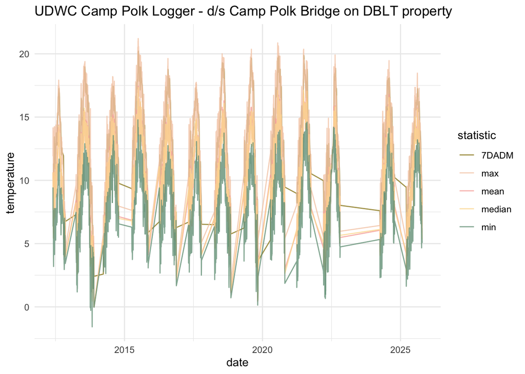

```r
ggplot() +
  geom_line(data = camp_polk_logger_historical, aes(x = date, y = temperature, color = statistic), alpha = 0.8) +
  scale_color_manual(values = colors_small) +
  theme_minimal() +
  ggtitle("UDWC Camp Polk Logger - d/s Camp Polk Bridge on DBLT property")
```

### Historical weather forecasts

Historical NWS weather forecasts were obtained from the [Open-Meteo Historical Forecast API](https://open-meteo.com/en/docs/historical-forecast-api), which archives operational GFS (Global Forecast System) model output — the same underlying model used by NWS to generate official forecasts. While NWS applies additional post-processing (Model Output Statistics and forecaster adjustments) before issuing public forecasts, the raw GFS output accessed through Open-Meteo represents the same meteorological signal and is expected to differ from official NWS values by only 1–3°C on any given day. For the purposes of this analysis, GFS-based forecasts are considered a suitable proxy for NWS forecast inputs given their shared model foundation and the daily temporal resolution of the model.

```
## `summarise()` has regrouped the output.
## ℹ Summaries were computed grouped by variable and type.
## ℹ Output is grouped by variable.
## ℹ Use `summarise(.groups = "drop_last")` to silence this message.
## ℹ Use `summarise(.by = c(variable, type))` for per-operation grouping
##   (`?dplyr::dplyr_by`) instead.
```

| variable | type | min_date | max_date | lead_days | n_NA |
| --- | --- | --- | --- | --- | --- |
| cloud_cover_mean | historical forecast | 2019-01-01 | 2026-04-14 | 1, 3, 7 | 2 |
| cloud_cover_mean | historical weather | 2011-01-01 | 2018-12-31 | 0 | 2 |
| temperature_2m_max | historical forecast | 2019-01-01 | 2026-04-14 | 1, 3, 7 | 2 |
| temperature_2m_max | historical weather | 2011-01-01 | 2018-12-31 | 0 | 2 |
| temperature_2m_min | historical forecast | 2019-01-01 | 2026-04-14 | 1, 3, 7 | 2 |
| temperature_2m_min | historical weather | 2011-01-01 | 2018-12-31 | 0 | 2 |

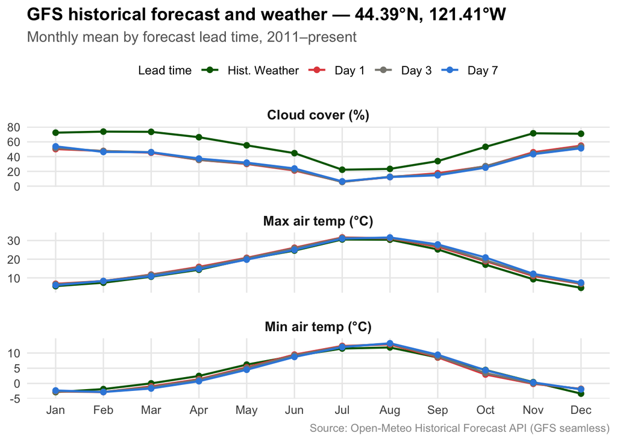

```r
# Single month test — run this first
one_month_historical <- get_historical_forecast(
  lat        = 44.390278,
  lon        = -121.406792,
  start_date = "2023-07-01",
  end_date   = "2023-07-31",
  lead_days  = c(1, 3, 7)
)

glimpse(one_month_historical)

# Historical forecast data from 2019-12-25 onwards (GFS archived model runs)
historical_forecast_data <- get_historical_forecast_range(
  lat        = 44.390278,
  lon        = -121.406792,
  start_date = "2019-01-01",
  end_date   = Sys.Date()-1,
  lead_days  = c(1, 3, 7),
  save_dir   = "data-raw/historical_forecasts"
) |>
  mutate(type = "historical forecast")

# Historical observed weather from 2011-01-01 to 2019-12-24 (ERA5 reanalysis)
# Uses same variables/schema as forecast data; issue_date and lead_days are NA
historical_weather_data <- get_historical_weather(
  lat        = 44.390278,
  lon        = -121.406792,
  start_date = "2011-01-01",
  end_date   = "2018-12-31"
) |>
  mutate(type = "historical weather")

all_historical_forecasts <- bind_rows(
  historical_weather_data,
  historical_forecast_data
) |>
  arrange(variable, valid_date)

usethis::use_data(all_historical_forecasts, overwrite = T)
```

### Camp Polk - one dataset

Combine OWRD and UDWC datasets into one Camp Polk dataset

```r
overlap <- inner_join(
  camp_polk_logger_historical |>
    filter(statistic == "max") |>
    mutate(date = as.Date(date)),
  camp_polk_historical |>
    filter(statistic == "max") |>
    filter(variable == "water temperature (c)") |>
    select(date, value),
  by = "date"
)

overlap |>
  mutate(diff = temperature - value) |>
  summarise(
    n = n(),
    mean_diff = mean(diff, na.rm = TRUE),
    max_diff  = max(abs(diff), na.rm = TRUE),
    cor       = cor(temperature, value, use = "complete.obs")
  )
```

```
## # A tibble: 1 × 4
##       n mean_diff max_diff   cor
##   <int>     <dbl>    <dbl> <dbl>
## 1  1865    -0.197     5.97 0.976
```

```r
camp_polk_temperature_historical <- camp_polk_historical |>
  filter(variable == "water temperature (c)") |>
  select(date, statistic, temperature = value) |>
  mutate(date = as.POSIXct(date)) |>
  anti_join(
    camp_polk_logger_historical |> mutate(date = as.POSIXct(as.Date(date))),
    by = c("date", "statistic")
  ) |>
  bind_rows(camp_polk_logger_historical) |>
  arrange(date, statistic) |> glimpse()
```

```
## Rows: 19,127
## Columns: 3
## $ date        <dttm> 2012-05-29, 2012-05-29, 2012-05-29, 2012-05-29, 2012-05-2…
## $ statistic   <chr> "7DADM", "max", "mean", "median", "min", "7DADM", "max", "…
## $ temperature <dbl> NA, 11.900000, 10.638000, 10.590000, 9.440000, NA, 14.1500…
```

```r
usethis::use_data(camp_polk_temperature_historical, overwrite = TRUE)
```

```
## ✔ Saving "camp_polk_temperature_historical" to
##   "data/camp_polk_temperature_historical.rda".
```

```
## ☐ Document your data (see <https://r-pkgs.org/data.html>).
```